# LSTM Initial data set exploration

Chris Dorich

June 3, 2022

Chris Dorich (chris.dorich@colostate.edu)  
June 3, 2022

# Data upload & management

```
##     SiteID               Date             Treatment             Crop
##  Length:505789      Min.   :1991-06-12   Length:505789      Length:505789
##  Class :character   1st Qu.:2006-01-08   Class :character   Class :character
##  Mode  :character   Median :2009-05-05   Mode  :character   Mode  :character
##                     Mean   :2008-04-02
##                     3rd Qu.:2011-03-14
##                     Max.   :2018-07-25
##
##  Fertilizer.kgN.ha  Fert.Type           Tillage.cm     Tillage.type
##  Min.   :   8.0    Length:505789      Min.   : 4.0     Length:505789
##  1st Qu.:  26.0    Class :character   1st Qu.:15.0     Class :character
##  Median :  46.0    Mode  :character   Median :20.0     Mode  :character
##  Mean   :  83.1                       Mean   :18.3
##  3rd Qu.:  67.0                       3rd Qu.:24.0
##  Max.   :1000.0                       Max.   :35.0
##  NA's   :505528                       NA's   :505514
##       Sand             Silt             Clay             tmax
##  Min.   :14.2     Min.   :11.7     Min.   : 1.3     Min.   :-36.92
##  1st Qu.:29.0     1st Qu.:22.0     1st Qu.:16.0     1st Qu.:  6.84
##  Median :31.0     Median :24.0     Median :19.0     Median : 18.12
##  Mean   :36.7     Mean   :28.6     Mean   :32.8     Mean   : 16.05
##  3rd Qu.:53.0     3rd Qu.:25.4     3rd Qu.:55.0     3rd Qu.: 26.37
##  Max.   :83.3     Max.   :67.8     Max.   :60.0     Max.   : 46.10
##  NA's   :487186   NA's   :487186   NA's   :487186   NA's   :60234
##       tmin             tavg         TotalnetRad          rain
##  Min.   :-24.5    Min.   :-34.2    Min.   : 0.0     Min.   :  0.00
##  1st Qu.:  3.4    1st Qu.:  2.6    1st Qu.: 7.5     1st Qu.:  0.00
##  Median : 13.1    Median : 12.8    Median :13.5     Median :  0.00
##  Mean   : 11.8    Mean   : 11.0    Mean   :13.9     Mean   :  1.95
##  3rd Qu.: 20.5    3rd Qu.: 20.1    3rd Qu.:19.6     3rd Qu.:  0.40
##  Max.   : 38.8    Max.   : 38.8    Max.   :51.5     Max.   :311.80
##  NA's   :376104   NA's   :349866   NA's   :492938   NA's   :42745
##  rain.irrigation       Dew            GSR.avg          humi.max
##  Min.   :  0.00   Min.   :-35.0    Min.   :  7.0    Min.   : 17.7
##  1st Qu.:  0.00   1st Qu.:  2.3    1st Qu.:119.0    1st Qu.: 79.2
##  Median :  0.00   Median :  6.8    Median :185.0    Median : 91.6
##  Mean   :  1.97   Mean   :  7.0    Mean   :215.4    Mean   : 85.7
##  3rd Qu.:  0.44   3rd Qu.: 13.0    3rd Qu.:297.0    3rd Qu.: 96.8
##  Max.   :311.80   Max.   : 25.3    Max.   :893.0    Max.   :103.7
##  NA's   :41898    NA's   :487127   NA's   :501998   NA's   :497378
```

[output cut: 57 more lines]

```
##  Min.   : -5258.0   Min.   :    0    Min.   :-136.0   Min.   :   0.0
##  1st Qu.:     6.3   1st Qu.: 1282    1st Qu.:   0.5   1st Qu.:   0.5
##  Median :  1408.5   Median : 2547    Median :   1.7   Median :   1.8
##  Mean   :  9757.3   Mean   : 3582    Mean   :  17.9   Mean   :  16.7
##  3rd Qu.: 15178.3   3rd Qu.: 4704    3rd Qu.:   6.2   3rd Qu.:   6.6
##  Max.   :326308.9   Max.   :58848    Max.   :8197.0   Max.   :8679.8
##  NA's   :463595     NA's   :495450   NA's   :420613   NA's   :464471
##    wfps.calc            pH              year          month
##  Min.   :  0.0    Min.   :4.4      Min.   :1991   Min.   : 1.000
##  1st Qu.: 37.3    1st Qu.:5.7      1st Qu.:2006   1st Qu.: 4.000
##  Median : 50.9    Median :6.1      Median :2009   Median : 7.000
##  Mean   : 51.2    Mean   :6.3      Mean   :2008   Mean   : 6.544
##  3rd Qu.: 65.7    3rd Qu.:7.2      3rd Qu.:2011   3rd Qu.: 9.000
##  Max.   :193.7    Max.   :8.5      Max.   :2018   Max.   :12.000
##  NA's   :448939   NA's   :505344
```

Likely issues that need to be corrected in the dataset:  
* fill in more soil texture and BD values  
* rain and rain.irrigation NAs  
* -100.00 soil.temp5 is not possible, must be an error in recording. Need to filter this out.  
* check WFPS values. Is 0.32 actually 0.32, or is it 32?  
* WFPS seems to be missing more often than I would have thought… researchers are using handheld soil moisture probe instead of monitoring constantly. This presents more uncertainty as the model will have to be training on more gap-filling WFPS data than originally thought.

Adding tillage and fertilization metrics.  
* Days since last till/fert event.

Excluded site-treatments with missing soil moisture or <40% of days with WFPS measurements:

- WFPS needs more gap-filling than originally thought.
- Will have to exclude these sites from the NN for now I think.

# Gap-filling/interpolation of covariates

Basic linear interpolation for covariates.

## Soil inorganic N decay curves

overly simplistic NO3/NH4 decay model…  
* what about the crop needs/existence  
* soil texture  
* what else could be worked in.

Test case looking at WagnerRiddle data:

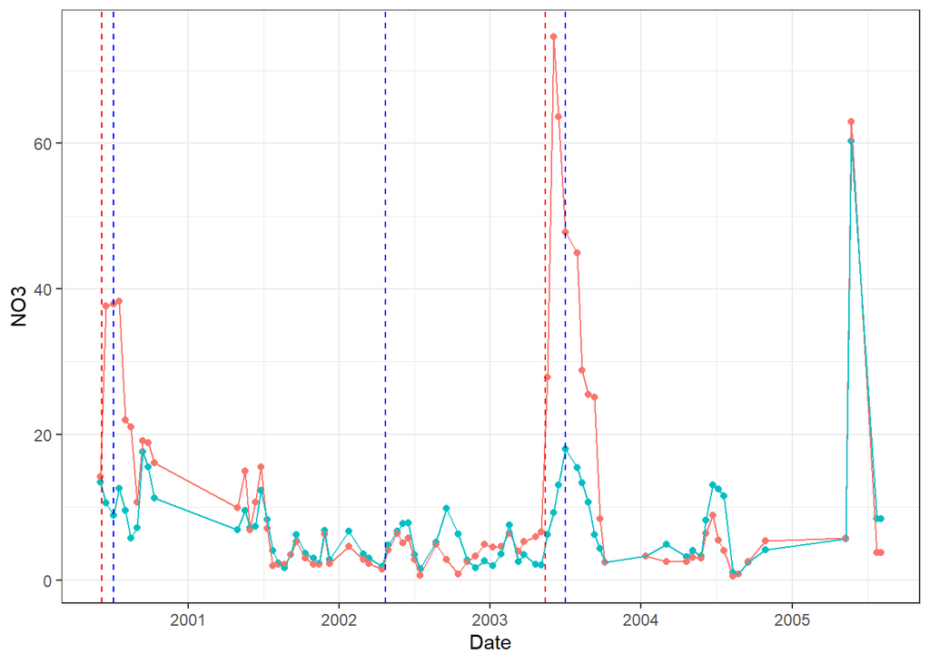

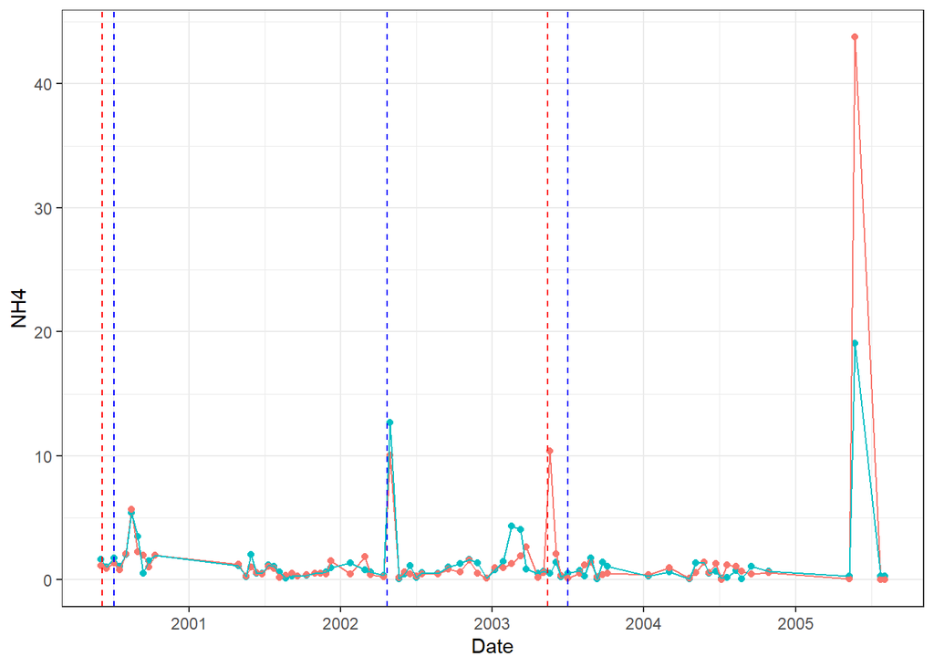

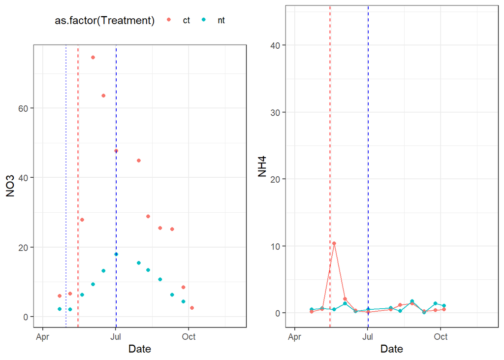

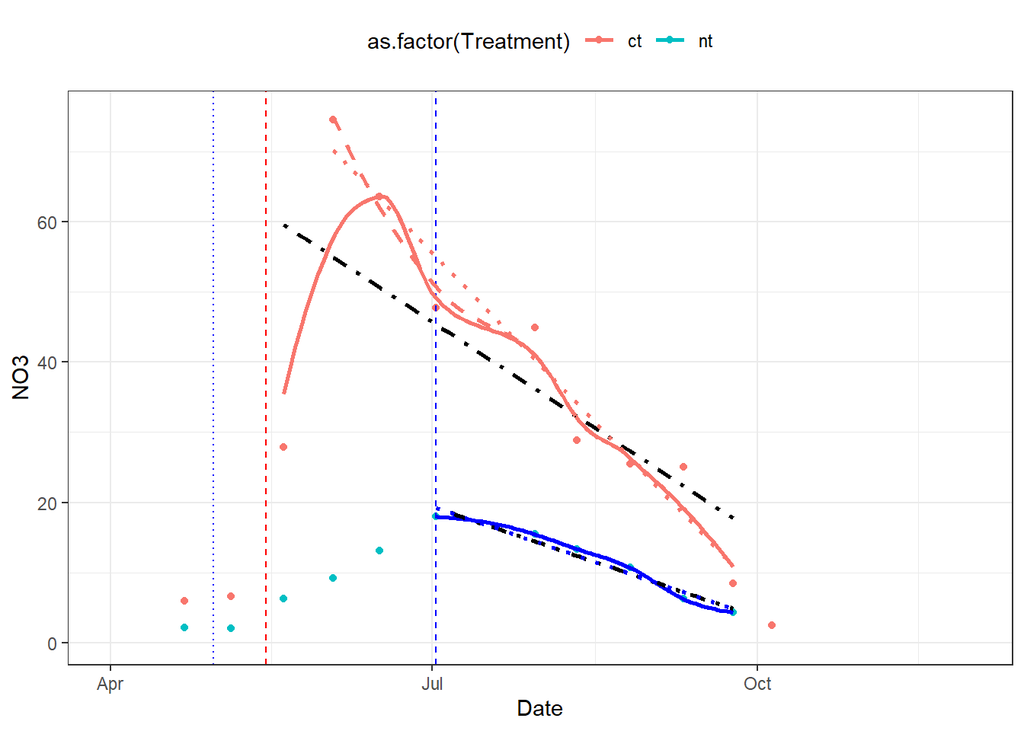

Notes on the figure:  
* The dashed vertical lines are when fertilizer was applied (160 for ct, 60 for nt)  
* The faint blue vertical dash is when red clover was killed at the nt site (explains why NO3 starts increasing shortly after)  
* The dashed lines amongst points are linear regressions from fert date, or from peak NO3.  
* The smoother lines are loess regressions from fert data, or from peak NO3.

Problems with gap-filling on soil inorganic N:  
* NO3 may not peak immediately after fertilization. Hard to determine what the peak would be/when it would occur. * linear regression from fert date (black line for ct) isn’t great. Would overestimate at first, but generally underestimate NO3.  
* Loess and linear regressions (for urea and this site-treatment case) from peak NO3 are fairly similar.

So, what options do we have for interpolation of soil inorganic N?

What about just using a continuous/constant value (the fertilizer.kgN.ha) as we know how much N was applied, and wont introduce our own error from interpolation, just provide another piece of info to the NN (how much N was applied) and see if it can infer/help with the inorganic N and time frame?

Soil inorganic N across sites, by N application type

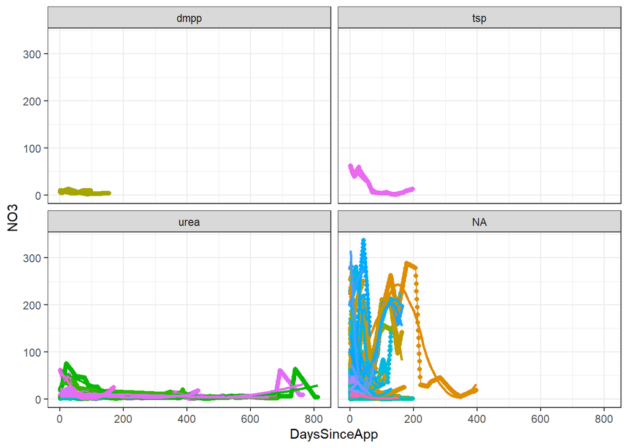

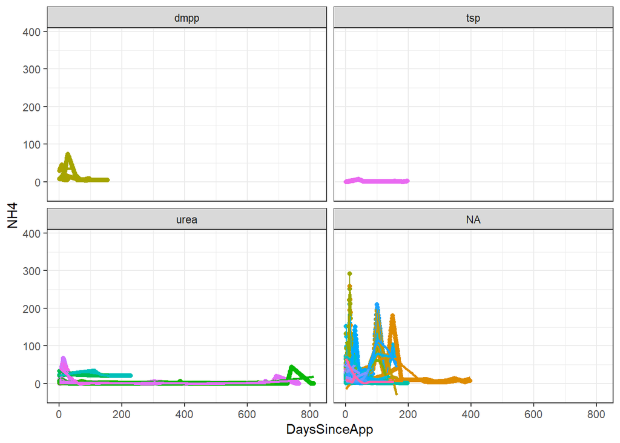

# Site-treatment breakdowns

|  | SiteID | Treatment | year | meanDailyn2o | Annn2o | days | n2ocounts | AnnPrecip | tavg | stemp5 | stemp10 | WFPS | wfps.calc | Fertilizer.kgN.ha | n |
| --- | --- | --- | --- | --- | --- | --- | --- | --- | --- | --- | --- | --- | --- | --- | --- |
| 1 | barton.79 | no.om.no.urea | 2013 | -6.49908645097289 | -2157.696701723 | 365 | 332 | 268.66 |  | 21.4306228373702 | 21.247508650519 | 6.51764102512 | 6.51764102512 | 0 | 365 |
| 2 | barton.79 | no.om.plus.urea | 2013 | -6.23502633741265 | -2070.028744021 | 365 | 332 | 268.66 |  | 21.4306228373702 | 21.247508650519 | 6.0732564096 | 6.0732564096 | 100 | 365 |
| 3 | barton.79 | om.no.urea | 2013 | -4.01110404361212 | -1323.664334392 | 365 | 330 | 268.66 |  | 21.4306228373702 | 21.247508650519 | 7.0360897428 | 7.0360897428 | 40 | 365 |
| 4 | barton.79 | om.plus.urea | 2013 | -4.0046428034006 | -1329.541410729 | 365 | 332 | 268.66 |  | 21.4306228373702 | 21.247508650519 | 7.25828205036 | 7.25828205036 | 140 | 365 |
| 5 | bel.18 | Early.Termination | 2013 | 31.0905852415153 | 8145.733333277 | 306 | 262 | 736.5 |  |  | 13.5130601093344 | 59.2564726027397 | 59.2564726027397 | 0 | 306 |
| 6 | bel.18 | Early.Termination | 2014 | 0.744632768288136 | 43.933333329 | 59 | 59 | 44.2 |  |  | 23.4033898310169 | 11.5418644067797 | 11.5418644067797 | 0 | 59 |
| 7 | bel.18 | Late.Termination | 2013 | 2.38625954466412 | 625.200000702 | 306 | 262 | 736.5 |  |  | 13.5130601737508 | 59.2564726027397 | 59.2564726027397 | 0 | 306 |
| 8 | bel.18 | Late.Termination | 2014 | 0.362146894915254 | 21.3666668 | 59 | 59 | 44.2 |  |  | 23.4033903389831 | 11.5418644067797 | 11.5418644067797 | 0 | 59 |
| 9 | bel.18 | Mowed.Pasture | 2013 | 0.52881679389313 | 138.55 | 306 | 262 | 736.5 |  |  | 13.5130601540984 | 59.2564726027397 | 59.2564726027397 | 0 | 306 |
| 10 | bel.18 | Mowed.Pasture | 2014 | 0.180790955932203 | 10.6666664 | 59 | 59 | 44.2 |  |  | 23.4033903389831 | 11.5418644067797 | 11.5418644067797 | 0 | 59 |

[output cut: 1457 more lines]

|  | SiteID | Treatment | meanDailyn2o | Annn2o | AnnPrecip | tavg | stemp5 | stemp10 | WFPS | wfps.calc | n |
| --- | --- | --- | --- | --- | --- | --- | --- | --- | --- | --- | --- |
| 1 | barton.79 | no.om.no.urea | -6.49908645097289 | -2157.696701723 | 268.66 |  | 21.4306228373702 | 21.247508650519 | 6.51764102512 | 6.51764102512 | 365 |
| 2 | barton.79 | no.om.plus.urea | -6.23502633741265 | -2070.028744021 | 268.66 |  | 21.4306228373702 | 21.247508650519 | 6.0732564096 | 6.0732564096 | 365 |
| 3 | barton.79 | om.no.urea | -4.01110404361212 | -1323.664334392 | 268.66 |  | 21.4306228373702 | 21.247508650519 | 7.0360897428 | 7.0360897428 | 365 |
| 4 | barton.79 | om.plus.urea | -4.0046428034006 | -1329.541410729 | 268.66 |  | 21.4306228373702 | 21.247508650519 | 7.25828205036 | 7.25828205036 | 365 |
| 5 | bel.18 | Early.Termination | 15.9176090049017 | 4094.833333303 | 390.35 |  |  | 18.4582249701757 | 35.3991685047597 | 35.3991685047597 | 365 |
| 6 | bel.18 | Late.Termination | 1.37420321978969 | 323.283333751 | 390.35 |  |  | 18.4582252563669 | 35.3991685047597 | 35.3991685047597 | 365 |
| 7 | bel.18 | Mowed.Pasture | 0.354803874912667 | 74.6083332 | 390.35 |  |  | 18.4582252465407 | 35.3991685047597 | 35.3991685047597 | 365 |
| 8 | bel.18 | Spring.Crop | 7.93039513315435 | 2046.16663355 | 390.35 |  |  | 18.4582252465407 | 35.3991685047597 | 35.3991685047597 | 365 |
| 9 | china_cs | C0N0 | 2.67433846153846 | 34.7664 | 374.7 | 26.3310344827586 |  |  |  |  | 87 |
| 10 | china_cs | C0N20 | 8.00104615384615 | 104.0136 | 374.7 | 26.3310344827586 |  |  |  |  | 87 |

[output cut: 426 more lines]

The LSTM is currently only using continuous rain and WFPS with occasional n2o provided every 5th day, with a sequence length of 30 days.

# Summary statistics

|  | SiteID | Treatment | n2o |
| --- | --- | --- | --- |
| 1 | barton.79 | no.om.no.urea | -2157.697 |
| 2 | barton.79 | no.om.plus.urea | -2070.029 |
| 3 | barton.79 | om.no.urea | -1323.664 |
| 4 | barton.79 | om.plus.urea | -1329.541 |
| 5 | bel.18 | Early.Termination | 8189.667 |
| 6 | bel.18 | Late.Termination | 646.567 |
| 7 | bel.18 | Mowed.Pasture | 149.217 |
| 8 | bel.18 | Spring.Crop | 4092.333 |
| 9 | china_cs | C0N0 | 34.766 |
| 10 | china_cs | C0N20 | 104.014 |

[output cut: 426 more lines]

[figure not shown]

Sum of n2o by covariate bins.

## N2O distribution

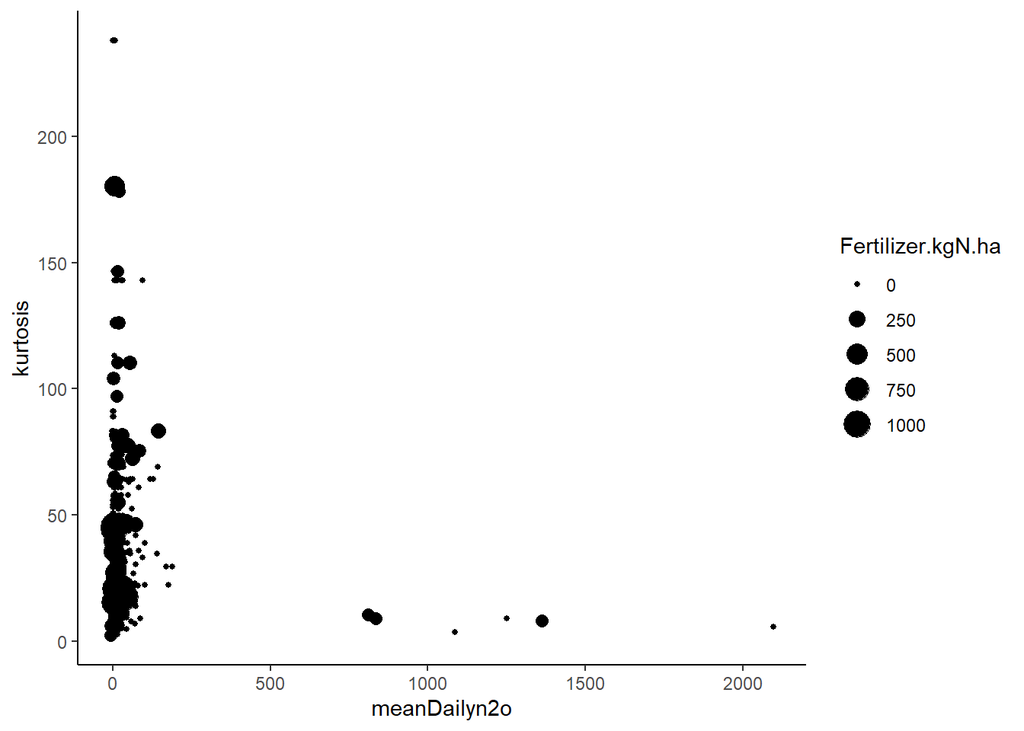

|  | Treatment | squareSkewness | kurtosis | SiteID | year | meanDailyn2o | Annn2o | days | n2ocounts | AnnPrecip | tavg | stemp5 | stemp10 | WFPS | wfps.calc | Fertilizer.kgN.ha | n |
| --- | --- | --- | --- | --- | --- | --- | --- | --- | --- | --- | --- | --- | --- | --- | --- | --- | --- |
| 1 | 0 | 0.159586395551052 | 2.61922624196554 | Ruan_2016 | 2011 | 2.043046875 | 65.3775 | 184 | 32 | 0 |  |  |  | 21.0487099365625 | 21.0487099365625 | 0 | 184 |
| 2 | 0n | 16.1949300521054 | 25.8593172134013 | dougherty.8 | 2014 | 2.17500309161491 | 700.3509955 | 332 | 322 | 714.2 |  |  | 17.2078429771242 | 69.9319171686747 | 69.9319879518072 | 0 | 332 |
| 3 | 100n | 19.5683416099147 | 27.2439781066228 | dougherty.8 | 2014 | 9.09308490652174 | 2927.9733399 | 332 | 322 | 714.2 |  |  | 17.2078429771242 | 69.9319171686747 | 69.9319879518072 | 500 | 332 |
| 4 | 112 | 11.9018282655266 | 15.6203454304248 | Ruan_2016 | 2011 | 14.748515625 | 471.9525 | 184 | 32 | 0 |  |  |  | 21.0487099365625 | 21.0487099365625 | 0 | 184 |
| 5 | 120mm_Irri | 6.14775444317419 | 10.1625846909086 | quayle.33 | 2014 | 13.880487804878 | 1707.3 | 123 | 123 | 185.2 | 20.9276422764228 |  | 22.1037735849057 | 65.47133125 | 65.47133125 | 0 | 123 |
| 6 | 140 | 10.0189882593956 | 14.145501611974 | Ruan_2016 | 2011 | 19.963125 | 638.82 | 184 | 32 | 0 |  |  |  | 21.0487099365625 | 21.0487099365625 | 0 | 184 |
| 7 | 168 | 9.41931726713647 | 13.5099193220499 | Ruan_2016 | 2011 | 28.971640625 | 927.0925 | 184 | 32 | 0 |  |  |  | 21.0487099365625 | 21.0487099365625 | 0 | 184 |
| 8 | 196 | 6.08070683070843 | 9.46131935261815 | Ruan_2016 | 2011 | 43.3490625 | 1387.17 | 184 | 32 | 0 |  |  |  | 21.0487099365625 | 21.0487099365625 | 0 | 184 |
| 9 | 25n | 17.9002986201088 | 23.9642980260157 | dougherty.8 | 2014 | 3.01061155217391 | 969.4169198 | 332 | 322 | 714.2 |  |  | 17.2078429771242 | 69.9319171686747 | 69.9319879518072 | 125 | 332 |
| 10 | 28 | 4.07018908039349 | 7.43086814950423 | Ruan_2016 | 2011 | 4.46484375 | 142.875 | 184 | 32 | 0 |  |  |  | 21.0487099365625 | 21.0487099365625 | 0 | 184 |

[output cut: 1457 more lines]

- skew - measure of the asymmetry of the probability distribution of a real-valued random variable about its mean. skewness for a normal distribution is zero, and any symmetric data should have a skewness near zero. Negative values for the skewness indicate data that are skewed left and positive values for the skewness indicate data that are skewed right.
- kurtosis - measure of the “tailedness” of the probability distribution of a real-valued random variable. High kurtosis tend to have heavy tails, or outliers.  
  [skew and kurtosis info](https://www.itl.nist.gov/div898/handbook/eda/section3/eda35b.htm)

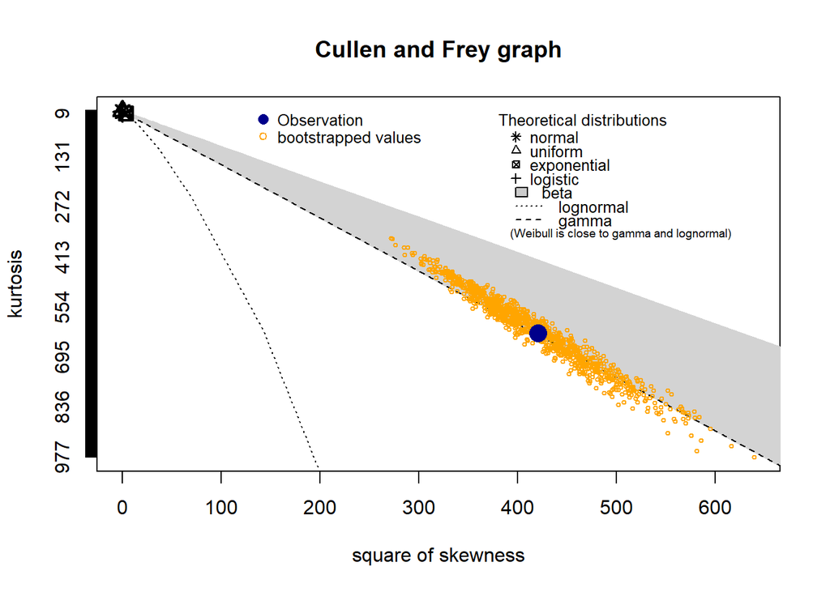

These cullen-frey graphs can be generated for all sites, but gives us an idea of what the distribution of n2o is like.

# Covariate Distributions

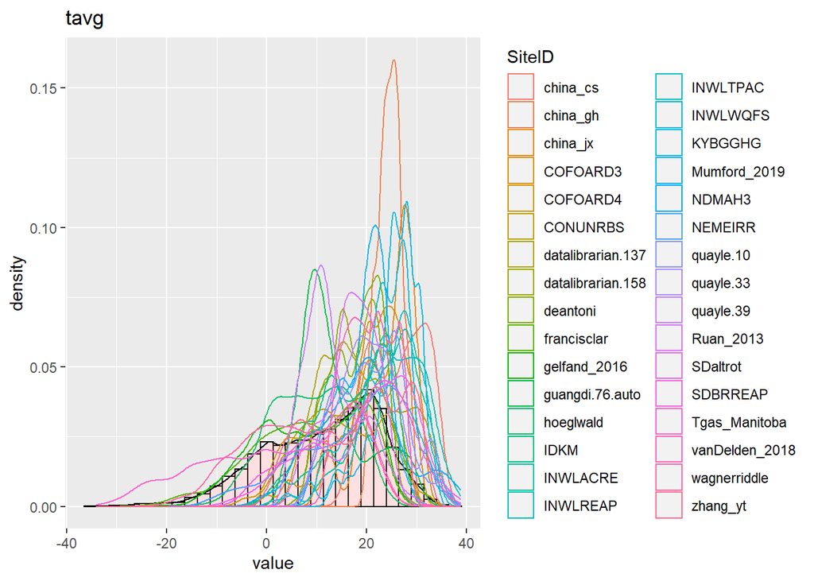

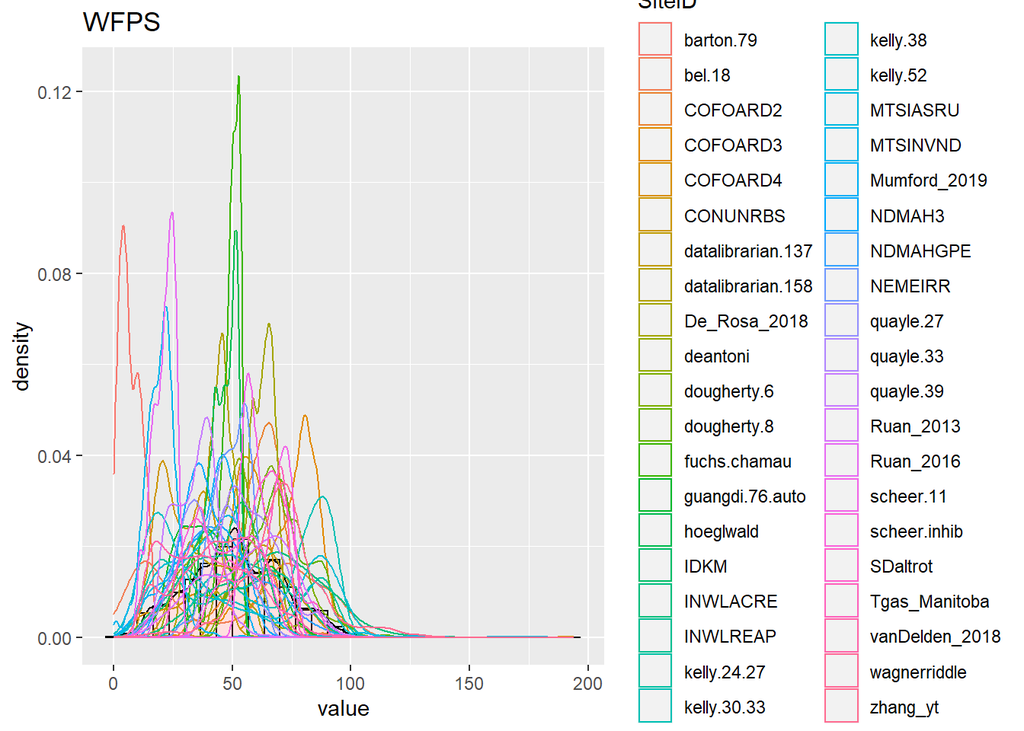

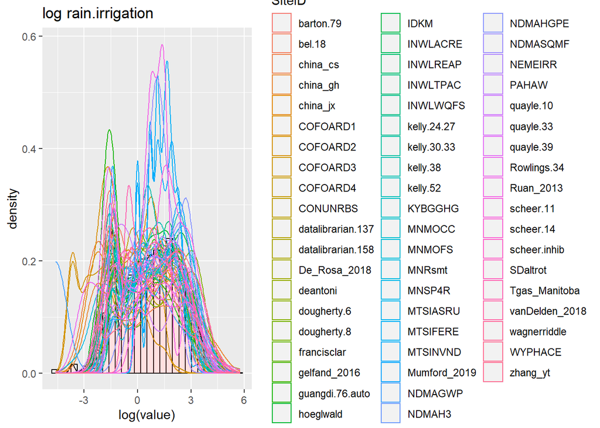

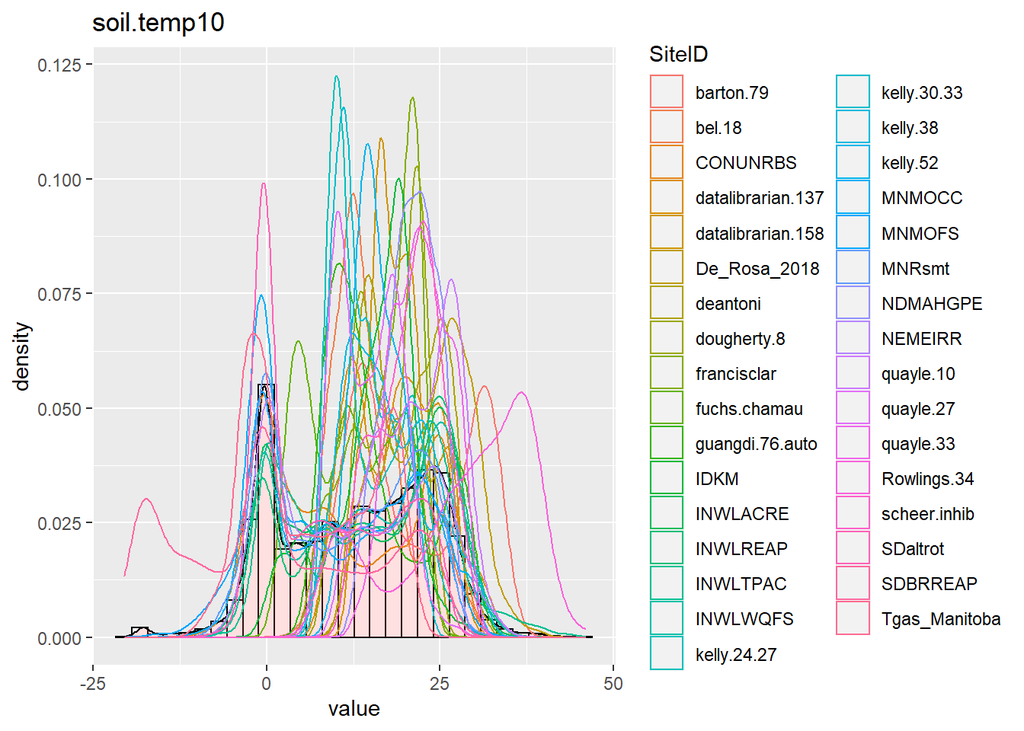

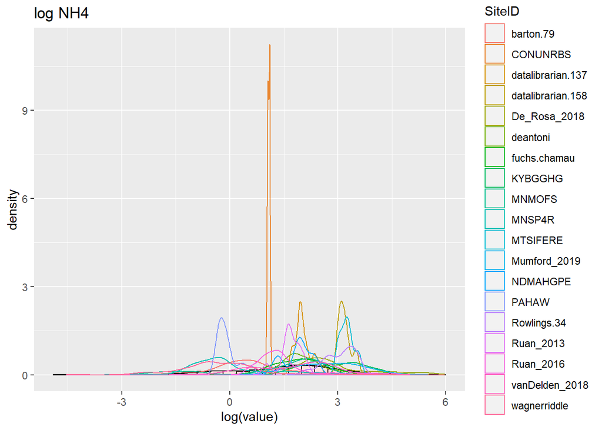

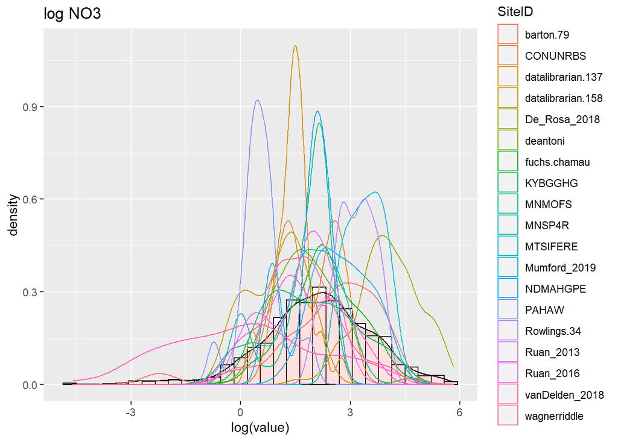

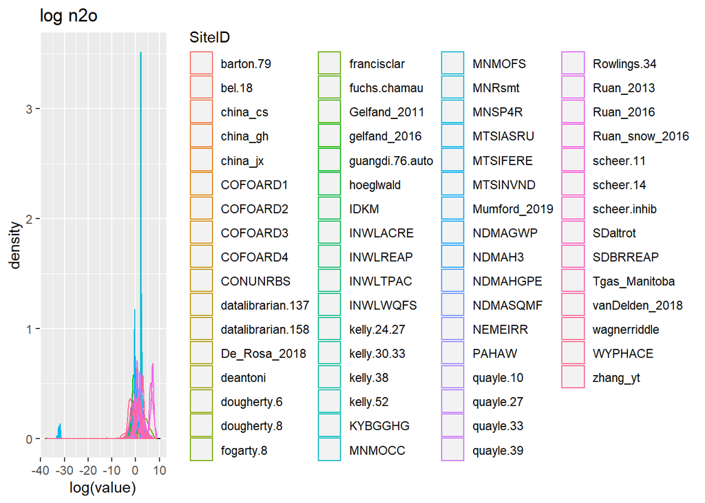

# Covariates examination

on raw, no gap-filling covariates (ie, NA values present in covariates)

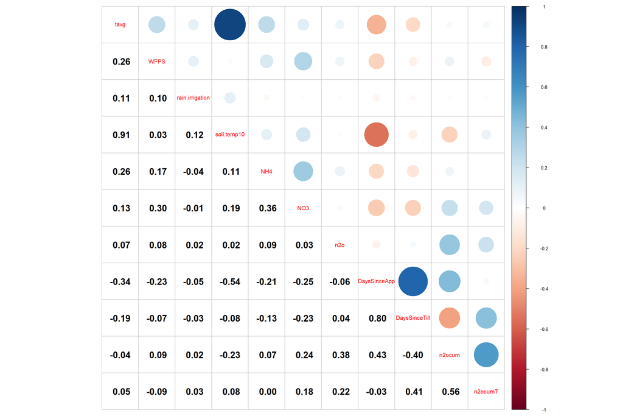

basic linear gap-filled covariate examination

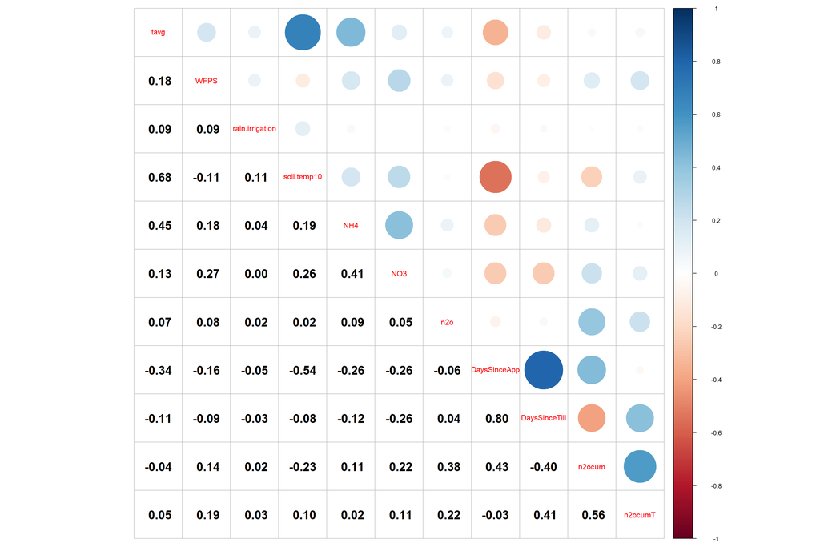

Comparison of raw covariates to n2o (noGF) to a linear interpolated covariates comparison to n2o (GF)

# Variable importance

More on variable importance [here](https://topepo.github.io/caret/variable-importance.html).  
[and here,](https://www.r-bloggers.com/2015/06/variable-importance-plot-and-variable-selection/) [and here](https://cran.r-project.org/web/packages/datarobot/vignettes/VariableImportance.html).

# Train-test-holdout data splits

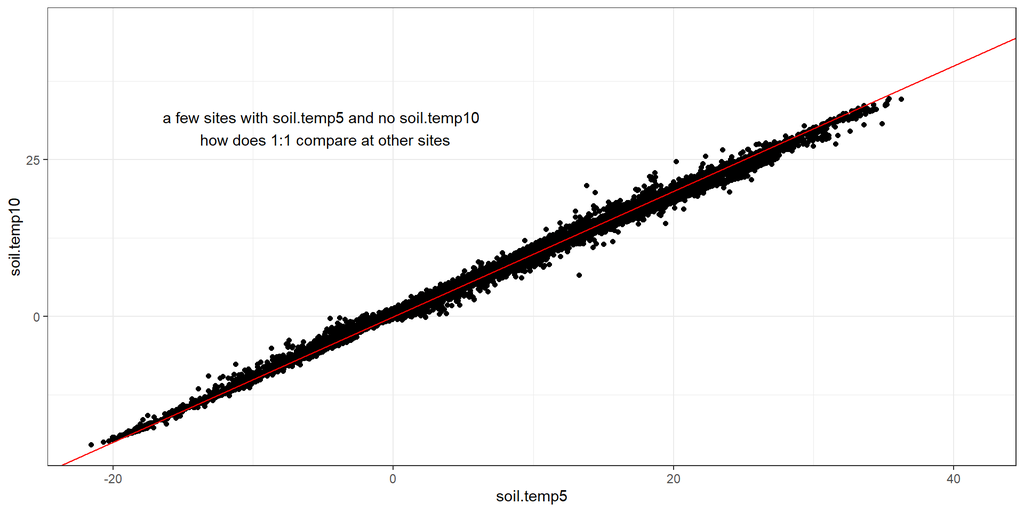

|  | SiteID | Treatment | n | Annn2o | meanDailyn2o | AnnPrecip | stemp10 | WFPS | stemp5 | tavg |
| --- | --- | --- | --- | --- | --- | --- | --- | --- | --- | --- |
| 1 | bel.18 | Early.Termination | 365 | 4094.833333303 | 15.9176090049017 | 390.35 | 18.4582249701757 | 35.3991685047597 |  |  |
| 2 | bel.18 | Late.Termination | 365 | 323.283333751 | 1.37420321978969 | 390.35 | 18.4582252563669 | 35.3991685047597 |  |  |
| 3 | bel.18 | Mowed.Pasture | 365 | 74.6083332 | 0.354803874912667 | 390.35 | 18.4582252465407 | 35.3991685047597 |  |  |
| 4 | bel.18 | Spring.Crop | 365 | 2046.16663355 | 7.93039513315435 | 390.35 | 18.4582252465407 | 35.3991685047597 |  |  |
| 5 | datalibrarian.137 | N000 | 309 | 80.943903525 | 0.262804881574675 | 266.4 | 18.8904761904762 | 51.7173509984615 |  | 16.6816993464052 |
| 6 | datalibrarian.137 | N040 | 309 | 154.046954254 | 0.500152448876623 | 266.4 | 18.8904761904762 | 51.7173509984615 |  | 16.6816993464052 |
| 7 | datalibrarian.137 | N120 | 309 | 251.110301945 | 0.815293188133117 | 266.4 | 18.8904761904762 | 51.7173509984615 |  | 16.6816993464052 |
| 8 | datalibrarian.137 | N200 | 309 | 242.75215001 | 0.788156331201299 | 266.4 | 18.8904761904762 | 51.7173509984615 |  | 16.6816993464052 |
| 9 | datalibrarian.158 | grass.0n | 282 | 132.89 | 2.30905152671756 | 413.4 | 22.1901507936508 | 46.5844173640167 |  | 20.8059828244275 |
| 10 | datalibrarian.158 | grass.100n | 282 | 715.56 | 7.9258320610687 | 413.4 | 22.1901507936508 | 46.5844173640167 |  | 20.8059828244275 |

[output cut: 63 more lines]

```
## [1] 73
```

```
## [1] 73
```